# ML Algorithms for clustring

Exercises and solutions

Hicham Zmarrou

Notebook – http://bit.ly/2q9NPSU

[Visit my website](http://trefoil.ml/) for more like this!

**References**

Most of this material is borrowed from:

- Textbook: [Practical Guide to Cluster Analysis in R](http://www.sthda.com)

## K-means

We’ll use the built-in R dataset USArrest which contains statistics, in arrests per 100,000 residents for assault, murder, and rape in each of the 50 US states in 1973. It includes also the percent of the population living in urban areas.

It contains 50 observations on 4 variables:

- [,1] Murder numeric Murder arrests (per 100,000)
- [,2] Assault numeric Assault arrests (per 100,000)
- [,3] UrbanPop numeric Percent urban population
- [,4] Rape numeric Rape arrests (per 100,000)
1. Load the `USArrests` data set, remove any missing value (i.e, NA values for not available) that might be present in the dat, View the firt 6

```r
# Load the data set
data("USArrests")
# Remove any missing value (i.e, NA values for not available)
# That might be present in the data
df <- na.omit(USArrests)
# View the firt 6 rows of the data
head(df, n = 6)
```

|  | Murder | Assault | UrbanPop | Rape |
| --- | --- | --- | --- | --- |
| Alabama | 13.2 | 236 | 58 | 21.2 |
| Alaska | 10.0 | 263 | 48 | 44.5 |
| Arizona | 8.1 | 294 | 80 | 31.0 |
| Arkansas | 8.8 | 190 | 50 | 19.5 |
| California | 9.0 | 276 | 91 | 40.6 |
| Colorado | 7.9 | 204 | 78 | 38.7 |

2. Before k-means clustering, compute `min`, `median`, `mean`, `sd` and `max` over all the states

Note that the variables have a large different means and variances. This is explained by the fact that the variables are measured in different units; Murder, Rape, and Assault are measured as the number of occurrences per 100 000 people, and UrbanPop is the percentage of the state’s population that lives in an urban area.

They must be standardized (i.e., scaled) to make them comparable. Recall that, standardization consists of transforming the variables such that they have mean zero and standard deviation one. You may want read more about standardization in the following article: [distance measures and scaling](http://bit.ly/1i7vgdY).

```r
desc_stats <- data.frame(
  Min = apply(df, 2, min), # minimum
  Med = apply(df, 2, median), # median
  Mean = apply(df, 2, mean), # mean
  SD = apply(df, 2, sd), # Standard deviation
  Max = apply(df, 2, max) # Maximum
  )
desc_stats <- round(desc_stats, 1)
head(desc_stats)
```

|  | Min | Med | Mean | SD | Max |
| --- | --- | --- | --- | --- | --- |
| Murder | 0.8 | 7.2 | 7.8 | 4.4 | 17.4 |
| Assault | 45.0 | 159.0 | 170.8 | 83.3 | 337.0 |
| UrbanPop | 32.0 | 66.0 | 65.5 | 14.5 | 91.0 |
| Rape | 7.3 | 20.1 | 21.2 | 9.4 | 46.0 |

3. As we don’t want the k-means algorithm to depend to an arbitrary variable unit, start by scaling the data using the R function `scale()`

```r
df <- scale(df)
head(df)
```

```
               Murder   Assault   UrbanPop         Rape
Alabama    1.24256408 0.7828393 -0.5209066 -0.003416473
Alaska     0.50786248 1.1068225 -1.2117642  2.484202941
Arizona    0.07163341 1.4788032  0.9989801  1.042878388
Arkansas   0.23234938 0.2308680 -1.0735927 -0.184916602
California 0.27826823 1.2628144  1.7589234  2.067820292
Colorado   0.02571456 0.3988593  0.8608085  1.864967207
```

4. Use the `fviz_nbclust()` in `factoextra` package to extract the optimal number of clusters

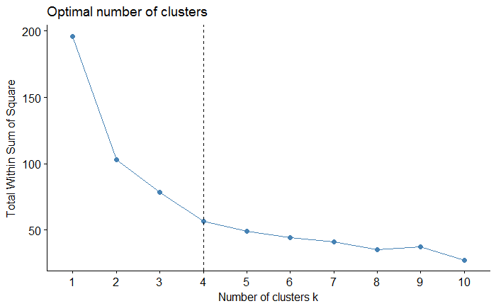

```r
library(factoextra)
set.seed(123)
fviz_nbclust(df, kmeans, method = "wss") +
    geom_vline(xintercept = 4, linetype = 2)
```

5. compute the k-means clustering with the suggested number of clusters

```r
# Compute k-means clustering with k = 4
set.seed(123)
km.res <- kmeans(df, 4, nstart = 25)
print(km.res)
```

```
K-means clustering with 4 clusters of sizes 13, 16, 13, 8

Cluster means:
      Murder    Assault   UrbanPop        Rape
1 -0.9615407 -1.1066010 -0.9301069 -0.96676331
2 -0.4894375 -0.3826001  0.5758298 -0.26165379
3  0.6950701  1.0394414  0.7226370  1.27693964
4  1.4118898  0.8743346 -0.8145211  0.01927104

Clustering vector:
       Alabama         Alaska        Arizona       Arkansas     California       Colorado    Connecticut       Delaware        Florida
             4              3              3              4              3              3              2              2              3
       Georgia         Hawaii          Idaho       Illinois        Indiana           Iowa         Kansas       Kentucky      Louisiana
             4              2              1              3              2              1              2              1              4
         Maine       Maryland  Massachusetts       Michigan      Minnesota    Mississippi       Missouri        Montana       Nebraska
             1              3              2              3              1              4              3              1              1
        Nevada  New Hampshire     New Jersey     New Mexico       New York North Carolina   North Dakota           Ohio       Oklahoma
             3              1              2              3              3              4              1              2              2
        Oregon   Pennsylvania   Rhode Island South Carolina   South Dakota      Tennessee          Texas           Utah        Vermont
             2              2              2              4              1              4              3              2              1
      Virginia     Washington  West Virginia      Wisconsin        Wyoming
             2              2              1              1              2

Within cluster sum of squares by cluster:
[1] 11.952463 16.212213 19.922437  8.316061
 (between_SS / total_SS =  71.2 %)

Available components:

[1] "cluster"      "centers"      "totss"        "withinss"     "tot.withinss" "betweenss"    "size"         "iter"
[9] "ifault"
```

6. Reaf the help of the function `fviz_cluster` in `factoextra` package and use it to plot the the result of th clustering.

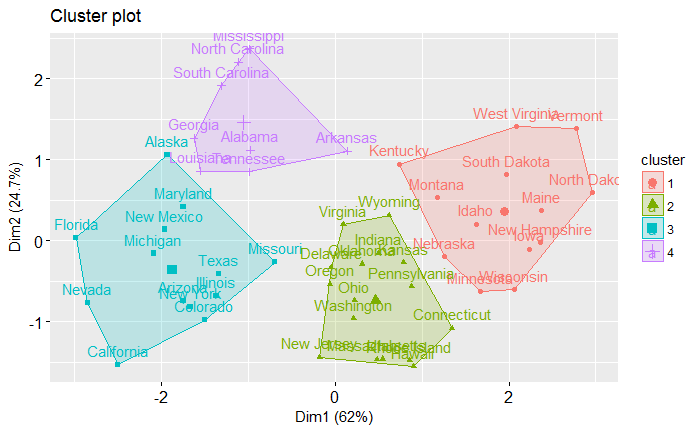

```r
fviz_cluster(km.res, data = df)
```

## K-medoids

1. Load the `cluster` package, the `USArrests` package, scale the data and compute pam with k = 4

```r
library("cluster")
# Load data
data("USArrests")
# Scale the data and compute pam with k = 4
pam.res <- pam(scale(USArrests), 4)
```

2. The function pam() returns an object of class pam which components include:
- medoids: Objects that represent clusters
- clustering: a vector containing the cluster number of each object

extract the cluster medoids using the `pam.res$medoids` attribute

```r
pam.res$medoids
```

```
                  Murder    Assault   UrbanPop         Rape
Alabama        1.2425641  0.7828393 -0.5209066 -0.003416473
Michigan       0.9900104  1.0108275  0.5844655  1.480613993
Oklahoma      -0.2727580 -0.2371077  0.1699510 -0.131534211
New Hampshire -1.3059321 -1.3650491 -0.6590781 -1.252564419
```

3. Extract clustering vectors

```r
head(pam.res$cluster,20)
```

```
    Alabama      Alaska     Arizona    Arkansas  California    Colorado Connecticut    Delaware     Florida     Georgia      Hawaii
          1           2           2           1           2           2           3           3           2           1           3
      Idaho    Illinois     Indiana        Iowa      Kansas    Kentucky   Louisiana       Maine    Maryland
          4           2           3           4           3           3           1           4           2
```

4. The result can be plotted using the function `fviz_cluster`, try also the function `clusplot()` [in cluster package] as follow:

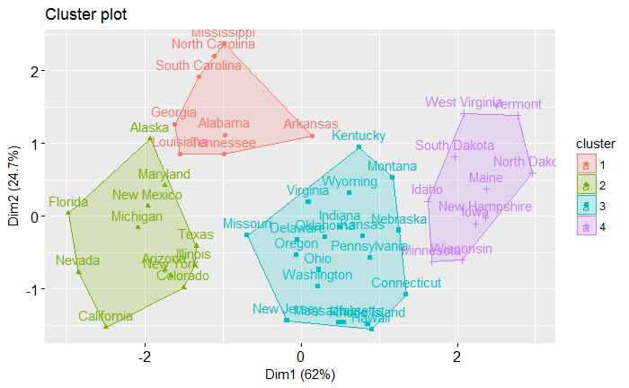

```r
fviz_cluster(pam.res)
```

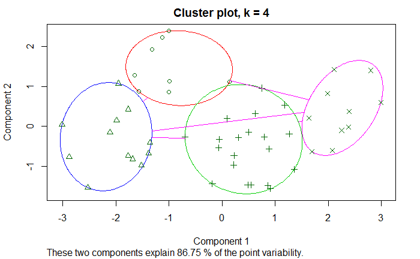

```r
clusplot(pam.res, main = "Cluster plot, k = 4",
         color = TRUE)
```

## DBSCAN

1. Load the `multishapes` data and make sure taht `fpc`;`dbscan` and `factoextra` are loaded.

```r
# Load the data
# Make sure that the package factoextra is installed
data("multishapes", package = "factoextra")
df <- multishapes[, 1:2]
```

2. The function `dbscan()` to clustwer the data and plot the results

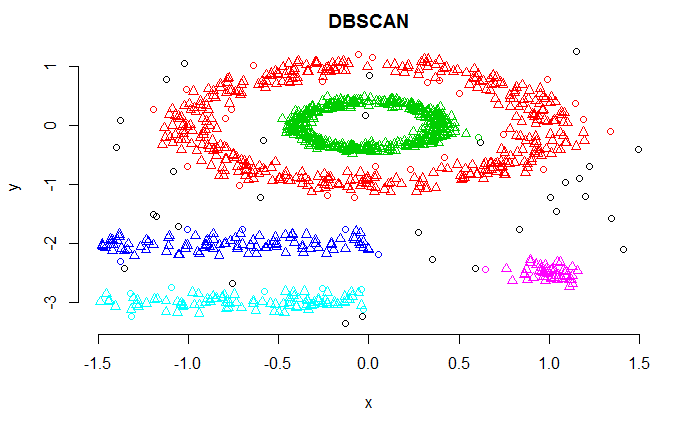

```r
library("fpc")
# Compute DBSCAN using fpc package
set.seed(123)
db <- fpc::dbscan(df, eps = 0.15, MinPts = 5)
# Plot DBSCAN results
plot.dbscan(db, df, main = "DBSCAN", frame = FALSE)
```

Note that, the function `plot.dbscan()` uses different point symbols for core points (i.e, seed points) and border points. Black points correspond to outliers. You can play with eps and MinPts for changing cluster configurations.

3. Compare k-means and DBSCAN algorithms and conclude for this data set.
4. plot the result of the DBSCAN clustering using the `fviz_cluster` function from the `factoextra` package

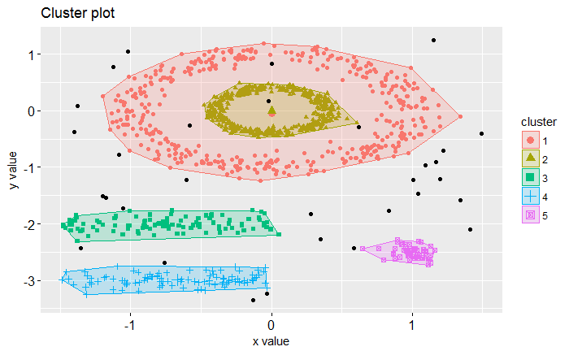

```r
library("factoextra")
fviz_cluster(db, df, stand = FALSE, ellipse = TRUE, geom = "point")
```

5. print the results of `fpc::dbscan()`

```r
# Print DBSCAN
print(db)
```

```
dbscan Pts=1100 MinPts=5 eps=0.15
        0   1   2   3  4  5
border 31  24   1   5  7  1
seed    0 386 404  99 92 50
total  31 410 405 104 99 51
```

Try to read the table

```
In the table above, column names are cluster number. Cluster 0 corresponds to outliers (black points in the DBSCAN plot).
```

6. Print the cluster membership using tje `$cluster` attribute

```r
# Cluster membership. Noise/outlier observations are coded as 0
# A random subset is shown
db$cluster[sample(1:1089, 50)]
```

```
 [1] 1 3 2 4 3 1 2 4 2 2 2 2 2 2 1 4 1 1 1 0 4 2 2 5 2 2 2 2 1 1 0 4 2 3 1 2 2 1 1 1 1 2 2 1 1 1 3 2 1 3
```

```
The function print.dbscan() shows a statistic of the number of points belonging to the clusters that are seeds and border points.
```

DBSCAN algorithm requires users to specify the optimal `eps` values and the parameter `MinPts`. In the R code above, we used eps = 0.15 and MinPts = 5. One limitation of DBSCAN is that it is sensitive to the choice of eps, in particular if clusters have different densities. If eps is too small, sparser clusters will be defined as noise. If eps is too large, denser clusters may be merged together. This implies that, if there are clusters with different local densities, then a single eps value may not suffice. A natural question is: How to define the optimal value of eps?

The method proposed here consists of computing the he k-nearest neighbor distances in a matrix of points.

The idea is to calculate, the average of the distances of every point to its k nearest neighbors. The value of k will be specified by the user and corresponds to MinPts.

Next, these k-distances are plotted in an ascending order. The aim is to determine the “knee”, which corresponds to the optimal eps parameter.

A knee corresponds to a threshold where a sharp change occurs along the k-distance curve.

The function kNNdistplot() [in dbscan package] can be used to draw the k-distance plot:

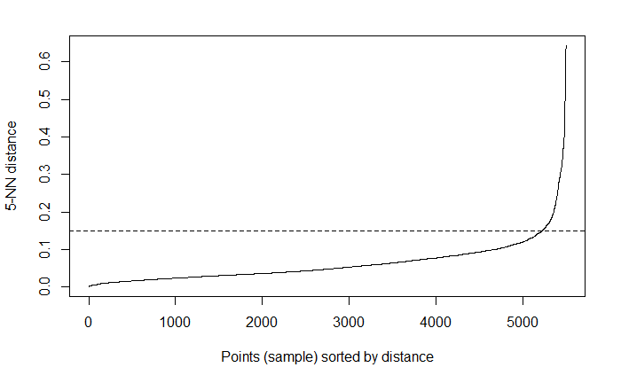

```r
dbscan::kNNdistplot(df, k =  5)
abline(h = 0.15, lty = 2)
```

### Cluster predictions with DBSCAN algorithm

The function `predict.dbscan(object, data, newdata)` [in `fpc` package] can be used to predict the clusters for the points in newdata. For more details, read the documentation (?predict.dbscan).

## Anomaly detection

### 2D ouliers

Anomaly detection is used for different applications. It is a commonly used technique for fraud detection. It is also used in manufacturing to detect anomalous systems such as aircraft engines. It can also be used to identify anomalous medical devices and machines in a data center. You can read more about anomaly detection from Wikipedia.

In this exercise, you will implement an anomaly detection algorithm to detect anomalous behavior in server computers. The features measure the throughput (mb/s) and latency (ms) of response of each server. While the servers were operating, we collected m = 307 examples of how they were behaving, and thus have an unlabeled dataset $ {x_1,,x_m}$. We suspect that the vast majority of these examples are " (non-anomalous) examples of the servers operating normally, but there might also be some examples of servers acting anomalously within this dataset.

You will use a Gaussian model to detect anomalous examples in the collected dataset. You will first start on a 2D dataset that will allow you to visualize what the algorithm is doing. On that dataset you will fit a Gaussian distribution and then find values that have very low probability and hence can be considered anomalies. After that, you will apply the anomaly detection algorithm to a larger dataset with many dimensions.

You can download the data for the first part of the exercise in RData format from “./data”/ folder.

The probability density function (PDF) of a multivariate normal is

$$f(X) = \frac{1}{(2\pi)^{\frac{k}{2}}} |\Sigma|^{\frac{-1}{2}} \exp(-{\frac{1}{2}}(X-\mu)^t\Sigma^{-1}(X-\mu))$$

$\Sigma$ is variance and $|\Sigma|$ is determinant of the variance. $\mu$ is mean and $k$ is number of columns (variables) of our data.

```r
load("./data/data1.RData")
# All the variables below are matrices
X=data1$X
Xval=data1$Xval   # This is cross-validation data
yval =data1$yval  # This shows which rows in Xval are anomalous
head(X)
```

```
         [,1]     [,2]
[1,] 13.04682 14.74115
[2,] 13.40852 13.76327
[3,] 14.19591 15.85318
[4,] 14.91470 16.17426
[5,] 13.57670 14.04285
[6,] 13.92240 13.40647
```

```r
head(Xval)
```

```
         [,1]     [,2]
[1,] 15.79026 14.92102
[2,] 13.63962 15.32996
[3,] 14.86590 16.47387
[4,] 13.58468 13.98931
[5,] 13.46404 15.63533
[6,] 12.94889 16.14007
```

```r
table(yval)
```

```
yval
  0   1
298   9
```

2. We will use a gaussian model to detect anomalous examples in our dataset. So, first, let’s check the distribution of the variables and see if they are approximately normally distributed. If they are not close to normal distribution, we have to use appropriate transformations to get good approximations of normal distribuions.
- convert $X$ to a data frame and give the names c(“Latency”, “Throughput”) to the columns
- plot the density distribution of the `Latency` and `Throughput` and conclude that are approximately normally distributed.
- repat for $Xval$

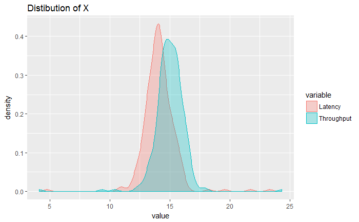

```r
X           <- as.data.frame(X)
colnames(X) <-  c("Latency", "Throughput")
XX          <- X %>% gather(variable, value, Latency, Throughput)
ggplot(XX, aes(x=value,fill=variable, color=variable))+ geom_density(alpha = 0.3)+ggtitle('Distibution of X')
```

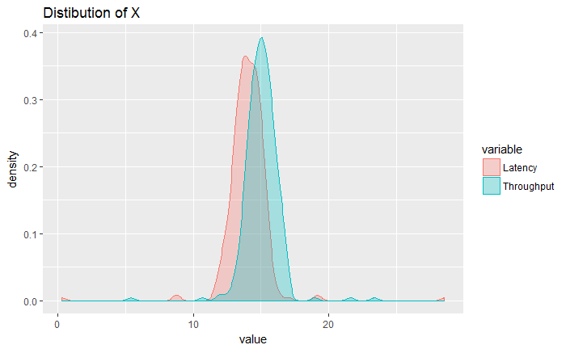

```r
Xval           <- as.data.frame(Xval)
colnames(Xval) <-  c("Latency", "Throughput")
XXval             <-  Xval %>% gather(variable, value, Latency, Throughput)
ggplot(XXval, aes(x=value,fill=variable, color=variable))+ geom_density(alpha = 0.3)+ggtitle('Distibution of X')
```

3. plot a 2D plot and see the joint distribution of Latency and Throughput.

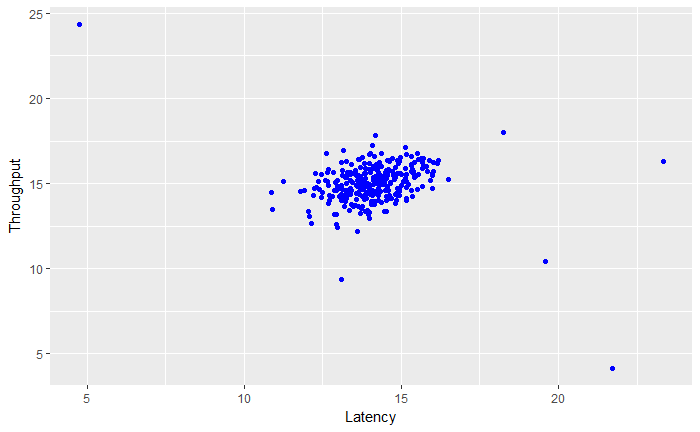

```r
ggplot(X,aes(x=Latency,y=Throughput))+geom_point(color='blue')
```

4. From the 2D plot detect visually the outliers.
5. In the probability density function (PDF) above, we have $X-\mu$. Subtract the mean from the data points and call this new data set X2. This is called centering

You can do it directly, I have used the caret package for this purpose.

```r
library(caret)
# Create preProcess object
preObj <- preProcess(X,method="center")
# Center the data- subtract the column means from the data points
X2 <- predict(preObj,X)
X2= as.matrix(X2)
```

6. Calculate variance of X2

```r
sigma2=var(X2)
# make it diagonal
sigma2= diag(sigma2)
sigma2= diag(sigma2)
sigma2
```

```
        [,1]     [,2]
[1,] 1.83862 0.000000
[2,] 0.00000 1.715333
```

Now we have estimated the Gaussian parameters, we can investigate which examples have a very high probability given this distribution and which examples have a very low probability. The low probability examples are more likely to be the anomalies in our dataset.

7. Calculate the probabilities using the multivariate normal distribution equation given above.

```r
A = (2*pi)^(-ncol(X2)/2)*det(sigma2)^(-0.5)
B = exp(-0.5 *rowSums((X2%*%ginv(sigma2))*X2))
p=A*B
```

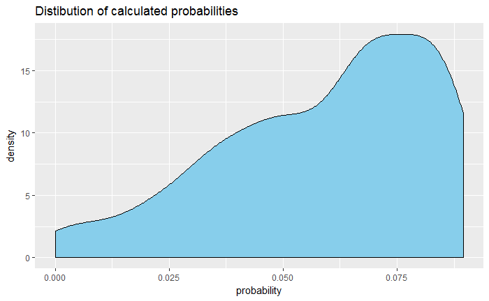

```r
p= p%>%as.data.frame()
names(p)= c('probability')
p%>%ggplot(aes(probability))+geom_density(fill='skyblue')+
ggtitle('Distibution of calculated probabilities')
```

From the density plot above, we see there are some values of the centralised data have very low probabilities which could be outliers. We can also plot a box plot of the probabilities. Here, I am also showing the points and this helps us to see the probabilities of each server.

We can also plot a box plot of the probabilities. Here, I am also showing the points and this helps us to see the probabilities of each server.

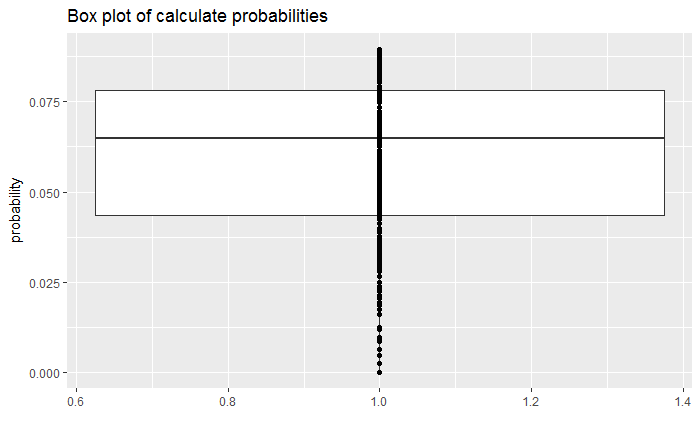

```r
library(plotly)
p%>%ggplot(aes(y=probability,x=1))+geom_boxplot()+
geom_point()+xlab('')+ggtitle("Box plot of calculate probabilities")
```

```r
# geom_jitter()+xlab('')+ggtitle("Box plot of calculate probabilities")
pp <- p%>%ggplot(aes(y=probability,x=1))+geom_boxplot()+
geom_jitter()+xlab('')+ggtitle("Box plot of calculate probabilities")
pptly <- ggplotly(pp)
pptly
```

[interactive chart not shown]

8. create a contour plot of the probabilities and see where the servers with highest probabilities are located.

```r
X= cbind(X,p)
pp <- ggplot(X, aes(x=Latency, y=Throughput, z=probability))+
geom_point()+ stat_density2d(color='red')
pptly <- ggplotly(pp)
pptly
```

[interactive chart not shown]

From the contour plot shown above, we see that most points are near the center and the contours show relatively higher probabilities in this region. We can see that the outliers are dispersed far away from the center of mass. When we are working with 2D data, we may be able to identify the outliers visually but this techniques is specially very useful when we are working with data with more than two dimensions.

To determine which of the points shown in the figure above are anomalous, we have to use cross-validation, as suggested in the corsera ML course. From cross-validation, we can get the cut-off probability to classify the servers as normal or anomalous. In data1.RData, Xval is the validation data and yval is the actual observation of the validation data (whether the servers were anomalous or not). We will use F1 score measure to get the threshould probability and also the accuracy of our model.

9. Repeat the process of centralisation and the calculation of the probabilities for the **Xval** set

```r
# Create preProcess object
Xval = as.data.frame(Xval)
preObj <- preProcess(Xval,method="center")
# Center the data- subtract the column means from the data points
Xval_centered <- predict(preObj,Xval)
# Then, calculate its variance.
Xval_centered = as.matrix(Xval_centered)
sigma2=diag(var(Xval_centered))
sigma2 = diag(sigma2)
sigma2
```

```
         [,1]     [,2]
[1,] 2.526098 0.000000
[2,] 0.000000 1.631331
```

```r
# Now, lcalculate pval of the cross-validation data Xval.
A=(2*pi)^(-ncol(Xval_centered)/2)*det(sigma2)^(-0.5)
B = exp(-0.5 *rowSums((Xval_centered%*%ginv(sigma2))*Xval_centered))
pval = A*B
```

For cross-validation, let’s use F1 score as suggested in the ML course, which uses *precision* and *recall* . Precision and rcall in turn are calculated using true positive, false positive and false negative as defined below.

- $t_p$ is the number of true positives: the label says it’s an anomaly and our algorithm correctly classied it as an anomaly.
- $f_p$ is the number of false positives: the label says it’s not an anomaly, but our algorithm incorrectly classied it as an anomaly.
- $f_n$ is the number of false negatives: the label says it’s an anomaly, but our algorithm incorrectly classied it as not being anomalous. The F1 score is computed using precision (prec) and recall (rec):

$$\text{prec} = \frac{t_p}{t_p+ f_p}$$
$$\text{rec} = \frac{t_p}{t_p+ f_n}$$
$$F_1 = 2.\frac{\text{prec}.\text{rec}}{\text{prec}+\text{rec}}$$
The code chunk below calculates the probability cutt-off value for the maximum possible F1 score through cross-validation.

```r
bestEpsilon = 0
bestF1 = 0
F1 = 0
stepsize = (max(pval) - min(pval)) / 1000
for (epsilon in seq(from =min(pval), by= stepsize,to =max(pval))){
    predictions = (pval < epsilon)*1

    tp = sum((predictions == 1) & (yval == 1))
    fp = sum((predictions == 1) & (yval == 0))
    fn = sum((predictions == 0) & (yval == 1))
    prec = tp / (tp + fp)
    rec = tp / (tp + fn)
    F1 = (2 * prec * rec) / (prec + rec)

 if (!is.na(F1)& (F1 > bestF1)==TRUE){
       bestF1 = F1
       bestEpsilon = epsilon

}
   }
cat("\n bestF1 =",round(bestF1,4))
```

```
 bestF1 = 0.875
```

```r
cat("\n bestEpsilon =",round(bestEpsilon,4))
```

```
 bestEpsilon = 2e-04
```

So, from the result above, the best F1 score from the cross-validation is 0.875.

10. Use the bestEpsilon above as cut-off to classify the servers as anomalous or normal

```r
X$outliers= X$probability < bestEpsilon
X$outliers=as.factor(X$outliers)
head(X)
```

|  | Latency | Throughput | probability | probability | outliers |
| --- | --- | --- | --- | --- | --- |
| 1 | 13.04682 | 14.74115 | 0.06456665 | 0.06456665 | FALSE |
| 2 | 13.40852 | 13.76327 | 0.05023525 | 0.05023525 | FALSE |
| 3 | 14.19591 | 15.85318 | 0.07226516 | 0.07226516 | FALSE |
| 4 | 14.91470 | 16.17426 | 0.05024677 | 0.05024677 | FALSE |
| 5 | 13.57670 | 14.04285 | 0.06354887 | 0.06354887 | FALSE |
| 6 | 13.92240 | 13.40647 | 0.04242358 | 0.04242358 | FALSE |

11. Calculate how many outliers we have according to our model and visualize which servers are outliers.

```r
table(X$outliers)
```

```
FALSE  TRUE
  301     6
```

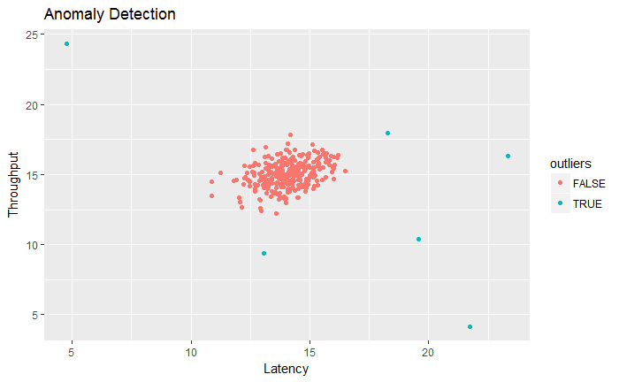

```r
X%>%ggplot(aes(x=Latency,y=Throughput))+
             geom_point(aes(color=outliers))+ggtitle('Anomaly Detection')
```

11. Extract the ouliers using the DBSCAN algorithm

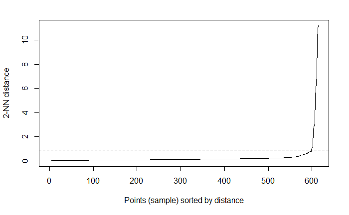

```r
library("fpc")
dbscan::kNNdistplot(X2, k =  2)
abline(h = 0.9, lty = 2)
```

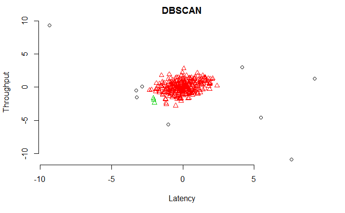

```r
# Compute DBSCAN using fpc package
dbX2 <- fpc::dbscan(X2, eps = 0.7, MinPts = 2)
# Plot DBSCAN results
plot.dbscan(dbX2, X2, main = "DBSCAN", frame = FALSE)
```

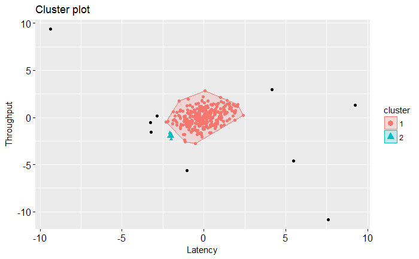

```r
fviz_cluster(dbX2, X2, stand = FALSE, ellipse = TRUE, geom = "point")
```

### Multidimensional Outliers

1. use the code from the previous part on a more realistic and much harder dataset. In this dataset, each example is described by 11 features, capturing many more properties of our compute servers. First load the `data2.RData` form “./data/”
2. Repeat the question 1. above using the `DBSCAN` algorithm.